# **Introduction to Data Science Long Assignment 2024/2025**

Group A

Pedro Miguel Leite Martins (202007065), Nina Lichtenberger (202408285), and Mariana de Saavedra Lourenço (201906985)

December 17

Contributions:

- Pedro Martins: code for the sections "Modeling with imbalanced data" and "Run Final Model on Test Data", 33% of the section "Data Understanding"
- Nina Lichtenberger: code for the sections "Modeling with balanced data" and "Final Comparison of Models", 33% of the section "Data Understanding", writing of the texts/comments for "Business Understanding", "Modeling with imbalanced data", "Modeling with balanced data", and "Final Comparison of Models"
- Mariana de Saavedra Lourenço: 33% of the section "Data Understanding", code and text for "Data Preparation"

## **Business Understanding**

The following report documents the building of a predictive model to classify if a company's customer has health insurance or not.

### *Business Objectives*

In the U.S., access to health insurance is crucial as it significantly impacts a customer's ability to manage medical expenses. Therefore, customers without health insurance are likely to have an interest in obtaining insurance. The goal of this project is to develop a predictive model that helps identify which customers of a broad insurance company are currently not enrolled for health insurance. By identifying these individuals, targeted outreach can be conducted.

This can help the business design intervention strategies to encourage uninsured customers to acquire health insurance, improving both individual financial security and public health outcomes.

Business success is achieved if the insights derived from the model are actionable and lead to improved customer outreach programs for uninsured individuals. To measure if uninsured individuals are worth pursuing as potential customers, it could be measured if the outreach campaigns based on the model lead to a certain amount of profit.

### *Assessment of Situation*

As the primary resource, a dataset with customer demographics and their insurance status was provided by the company. The available customer information contain:

- Sex
- Employment Status
- Income
- Marital Status
- Housing Type
- Number of Vehicles
- Age
- State of Residence
- Gas Usage
- Number of Rooms
- Recent Move

The dataset was, however, provided uncleaned and must be cleaned, consistent, and free of missing or erroneous values before modeling. If substantial data issues arise, strategies like imputation or alternative modeling techniques (e.g., undersampling or oversampling) will be employed to mitigate risks. The model should handle both balanced and imbalanced versions of the data.

Moreover, it should be considered that it is assumed that customer attributes like age, income, and employment status are significant predictors of health insurance status and that the sample data is representative of the customer population.

Regarding limitations, there may be limited data on certain demographic groups, which could introduce bias. The imbalanced nature of insurance coverage in the dataset may also skew predictions. Moreover, the insights might be specific for the customers of the analyzed company and not to be generalized to the US population or the customers of other companies since every company attracts different kinds of clients, leading to a prefiltered sample. To achieve business success, it is also crucial that the stakeholders have knowledge about the model and how to use its insights. Therefore, close communication with the sales and marketing department is necessary to make the results of the model actionable.

The main cost of this project is the time and resources to clean data, build models, and evaluate results. The potential benefit is the income generated by the clients, detected as uninsured, who can specifically be targeted for health insurance advertisements. To assess the cost/benefit ratio it is crucial to measure if the additional profit of targeted campaigns offsets the cost.

### *Data Mining Goals*

The data mining goal is to develop a classification model that predicts whether a customer has health insurance based on their demographic and financial attributes. The model will be evaluated on its ability to classify insurance status correctly, also on unseen data.

The data mining success will primarily be measured by the F1 score, but also other performance metrics such as precision, and recall will be taken into account.

# **Data Understanding**

```python
# import the necessary libraries
import pandas as pd
import numpy as np
import os
import seaborn as sns
import matplotlib.pyplot as plt
import geopandas as gpd
import plotly.express as px
from sklearn.preprocessing import OneHotEncoder, LabelEncoder, StandardScaler, PolynomialFeatures
from sklearn.model_selection import train_test_split, cross_val_score, cross_val_predict, GridSearchCV, RandomizedSearchCV
from sklearn.linear_model import LogisticRegression
from sklearn.metrics import accuracy_score
from sklearn.impute import SimpleImputer
from sklearn.neighbors import KNeighborsClassifier
from sklearn.naive_bayes import GaussianNB
from sklearn.linear_model import SGDClassifier
from sklearn.neural_network import MLPClassifier
from sklearn.metrics import confusion_matrix, precision_score, recall_score, f1_score, classification_report
from sklearn.utils import shuffle
from sklearn.feature_selection import SelectKBest
from sklearn.feature_selection import mutual_info_classif
from sklearn.svm import SVC
from sklearn.tree import DecisionTreeClassifier
from sklearn.ensemble import RandomForestClassifier
from sklearn.metrics import roc_curve, roc_auc_score, make_scorer, recall_score
from sklearn.datasets import make_classification
from scipy.stats import chi2_contingency
from imblearn.over_sampling import SMOTE
from imblearn.under_sampling import RandomUnderSampler
from imblearn.pipeline import Pipeline
from collections import Counter
import xgboost as xgb
from google.colab import drive

# ignore warning errors to prevent unnecessary outputs
from warnings import filterwarnings
filterwarnings('ignore')
```

```python
# import data
customer = pd.read_csv("customer.csv")
customer_test_masked = pd.read_csv("customer_test_masked.csv")
```

```python
# explore data
customer.head()
```

```python
customer.info()
```

The summary of the columns shows that we have two unnecessary columns and some columns which are encoded as floats even though they are integer values.

```python
# Check the number of NAs
customer.isnull().sum()
```

The fact that the amount of rows with NAs for housing_type, num_vehicles, gas_usage and recent_move_b is the same implies that these are the same rows. Considering that there are so many variables missing for these clients as well as that we have almost 75,000 observations, it is the best to drop the 1687 rows. In this way, we still have enough observations while not having the risk of making false assumptions (e.g. by imputing the mean). However, the number of NAs in the employment status is very high with 25,000. Therefore, we should not simply drop the rows with missing values and find out what causes the missing values in this column.

```python
# show unique values of is_employed
customer['is_employed'].unique()
```

```python
# create subset to explore what could be the reason for NAs
employ_NA = customer[customer['is_employed'].isnull()]
```

```python
# check if the numerical columns, especially income, reveal something about the employment status
employ_NA.describe()
```

```python
# display the statistics for the numerical columns separately for the unemployed and employed clients to see if the NAs resemble one group more
customer[customer['is_employed']==False].describe()
```

```python
customer[customer['is_employed']==True].describe()
```

```python
# compare the unique values of the complete dataset and the NAs to check if e.g. the employment status is unknown for all residents of one state
customer.nunique()
```

```python
employ_NA.nunique()
```

The analysis of the NAs in the employment status column implies that the NAs can be interpreted as "unemployed". The unique values of the categorical variables show no difference to the complete dataset. When comparing the income of the NAs with the income of the employed and unemployed group, it does, however, become visible that the NAs have an average and median income closer to the unemployed group. The employed customers have a significantly higher average and median income than the NA group. Therefore, it will be assumed that the NAs can be interpreted as "unemployed".

```python
# check for outliers in the numerical columns
customer.describe()
```

When looking at the statistics of the numerical columns of our dataset, we note the following striking values that should not be ignored.

- Minimum income value is negative
- Minimum age value of 0 years
- Maximum age value of 120 years

```python
# Count the number of rows where income is less than 0
customer[customer['income'] < 0]['income'].count()
```

```
45
```

The observations with a negative income imply that a person's expenses are exceeding their income. Given that the number of observations with an income smaller than 0 is only 45 and can be considered outliers which might influence our results negatively, we can simply drop these rows without losing much information. We will check if the same is true for the age values which seem unrealistic.

```python
# count the number of rows where the age is 0 or above 100
customer[(customer['age'] == 0) | (customer['age'] > 100)]['age'].count()
```

```
268
```

The number of rows with an age of 0 or above 100 is also relatively small, wherefore these rows will be dropped, too. In this way, we will not distort our information by e.g. imputing the mean.

Our analysis showed that, in total, we have 12 variables including the target variable. Our variables include:

- Sex (binary)
- Employment Status (binary)
- Income (ratio-scaled)
- Marital Status (nominal)
- Housing Type (nominal)
- Number of Vehicles (ratio-scaled)
- Age (ratio-scaled)
- State of Residence (nominal)
- Gas Usage (ratio-scaled)
- Number of Rooms (ratio-scaled)
- Recently Moved (binary)
- Health Insurance Status (binary) - target variable

Now that we have already identified some outliers and inconsistencies with summaries, we will proceed to explore our data and perform preliminary analyses in the form of visualizations.

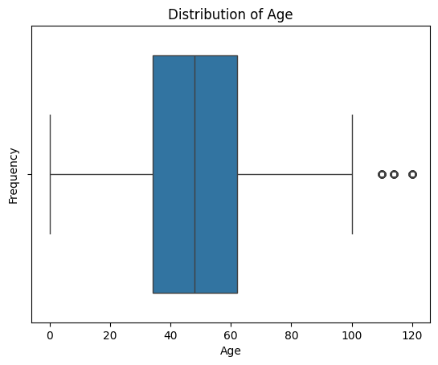

```python
# create boxplot to display the distribution of age
sns.boxplot(x = customer["age"])
plt.title('Distribution of Age')
plt.xlabel('Age')
plt.ylabel('Frequency')
plt.show()
```

In our dataset we have clients from every age group. The boxplot does, however, show that the majority of clients are middle-aged to senior, meaning people in the age range of 30 to 60. Therefore, the results of our analysis and model will be especially applicable to this group of people. To obtain insights about how to best target young customers, another dataset would have to be used. The variables in our dataset - for example, income and housing type - are highly dependent on age. People in their 20s are more likely to have lower incomes and not live in owned houses or apartments, for example. Therefore, the variables will correlate with age and our model may be biased.

```python
# check the number of individuals with income = 0
customer[customer['income'] == 0]['income'].count()
```

```
6691
```

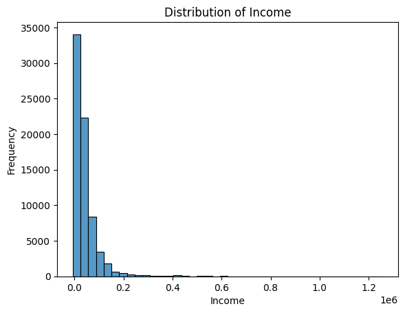

```python
# create histogram to get an overview of the distribution of income
sns.histplot(customer['income'], bins=40)
plt.title('Distribution of Income')
plt.xlabel('Income')
plt.ylabel('Frequency')
plt.show()
```

```python
print("Mean income: ", round(customer['income'].mean(),2))
print("Median income: ", round(customer['income'].median(),2))
```

```
Mean income:  41881.43
Median income:  26400.0
```

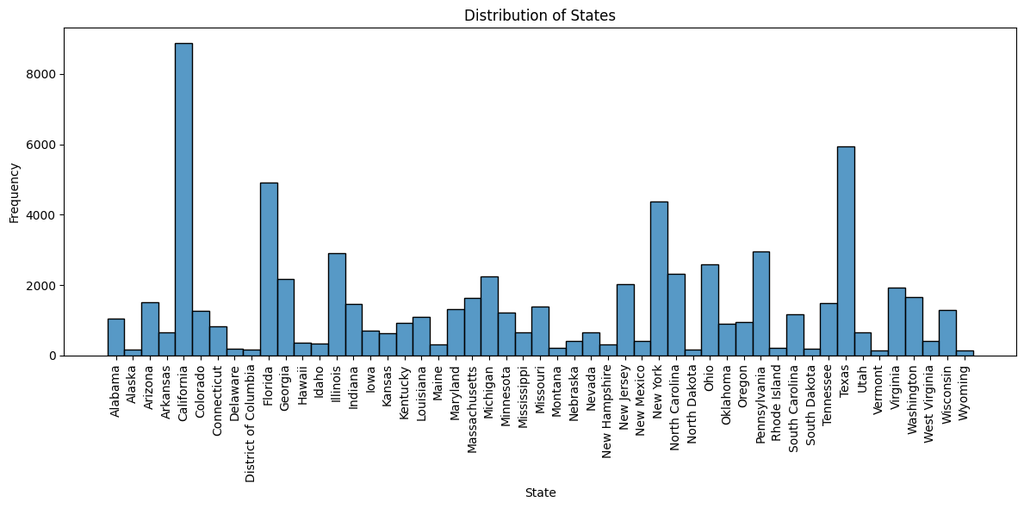

```python
# create histogram to get an overview of the residence states
plt.figure(figsize=(12, 6))
sns.histplot(customer['state_of_res'], bins=40)
plt.title('Distribution of States')
plt.xlabel('State')
plt.xticks(rotation=90)
plt.ylabel('Frequency')
plt.tight_layout()
plt.show()
```

```python
# check how many observations we have for the states with the least amount of observations
customer[customer['state_of_res'] == 'Wyoming'].shape[0]
```

```
130
```

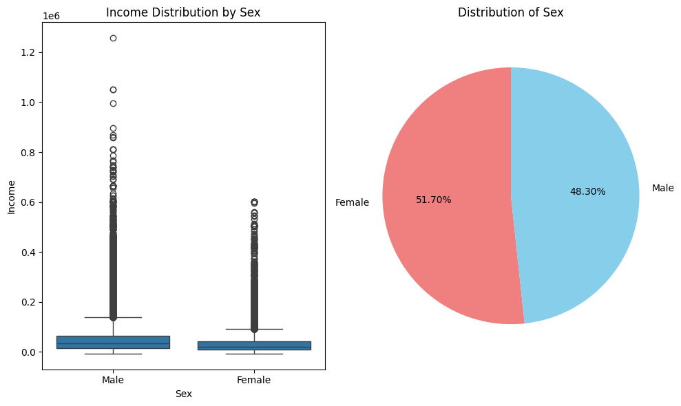

```python
fig, axes = plt.subplots(1, 2, figsize=(10, 6), )  # 1 row, 2 columns

# Plot Income Distribution by Sex on the first subplot
sns.boxplot(x='sex', y='income', data=customer, ax=axes[0])
axes[0].set_xlabel('Sex')
axes[0].set_ylabel('Income')
axes[0].set_title('Income Distribution by Sex')

# Plot Distribution of Sex on the second subplot
sex_counts = customer['sex'].value_counts()
axes[1].pie(sex_counts, labels=sex_counts.index, autopct='%.2f%%', startangle=90, colors=['lightcoral', 'skyblue'])
axes[1].set_title("Distribution of Sex")
axes[1].axis('equal')

# Adjust layout and display the plot
plt.tight_layout()
plt.show()
```

```python
# check for differences in income based on sex, marital situation and age
sex_income = customer.groupby('sex')['income'].median()
print("Incomes:")
print("Male: ", round(sex_income["Male"]))
print("Female: ", round(sex_income["Female"]))
```

```
Incomes:
Male:  34600
Female:  20000
```

The median and boxplots show that there is a significant difference in the income of men and women. Women tend to earn less income - the female median is less than 60% of the male median. This might be caused by different reasons. Firstly, there is a well-documented phenomenon called "gender pay gap" which states that women tend to get a lower salary in the same jobs as men. Moreover, more women stay at home instead of working or choose social professions, which usually lead to a lower salary. According to a study of the Pew Research center based on median hourly earnings of both full- and part-time, women in the US earned only 82 cents for every dollar earned by men in 2022 (Kochhar, 2023). In our sample, it is also striking that the male group has a significantly higher amount of outliers in the high salary levels.

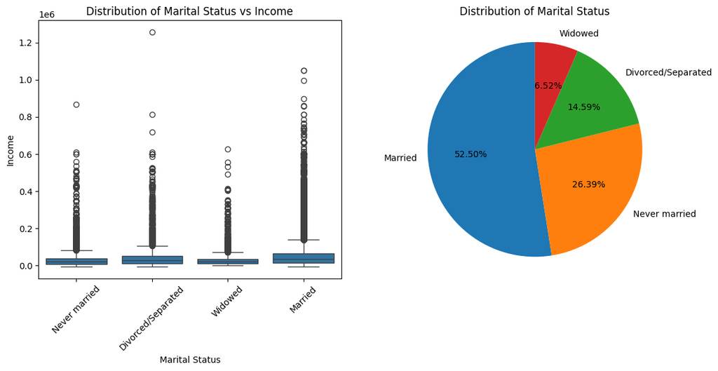

```python
fig, axes = plt.subplots(1, 2, figsize=(12, 6))

# Plot Income Distribution by marital status on the first subplot
sns.boxplot(x='marital_status', y='income', data=customer, ax=axes[0])
axes[0].set_xlabel('Marital Status')
axes[0].set_ylabel('Income')
axes[0].set_title('Distribution of Marital Status vs Income')
axes[0].set_xticklabels(axes[0].get_xticklabels(), rotation=45)

# Plot Distribution of Sex on the second subplot
marital_counts = customer['marital_status'].value_counts()
axes[1].pie(marital_counts, labels=marital_counts.index, autopct='%.2f%%', startangle=90)
axes[1].set_title("Distribution of Marital Status")
axes[1].axis('equal')

# Adjust layout and display the plot
plt.tight_layout()
plt.show()
```

```python
marital_status_income = customer.groupby('marital_status')['income'].median()

print("Incomes:")
print("Never married: ", round(marital_status_income["Never married"],2))
print("Divorced/Separated: ", round(marital_status_income["Divorced/Separated"],2))
print("Widowed: ", round(marital_status_income["Widowed"],2))
print("Married: ", round(marital_status_income["Married"],2))
```

```
Incomes:
Never married:  20000.0
Divorced/Separated:  26340.0
Widowed:  19700.0
Married:  33000.0
```

Furthermore, it is evident that married and divorced people tend to have a higher income. The difference between the median income of a married person and a person who has never married is almost as big as the difference between men and women. This may be due to various reasons. In married households, there is often the potential for dual incomes. This can lead to higher household earnings or tax benefits when compared to single individuals or those who have never married. Marriage can also provide financial stability, allowing couples to invest in education, property, and other wealth-building assets. Lastly, married individuals may prioritize stable, higher-paying jobs to support their family. This focus can lead to career advancement and higher income. Some of these financial advantages are sustainable, wherefore they can also explain the higher income of divorced individuals.

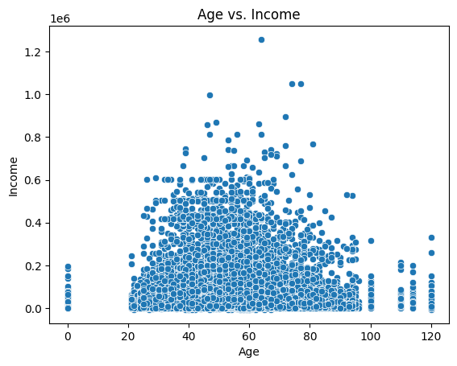

```python
sns.scatterplot(x='age', y='income', data=customer)
plt.title('Age vs. Income')
plt.xlabel('Age')
plt.ylabel('Income')
plt.show()
```

Although it might be assumed that income increases with age due to career advancement, this is only evident in the maximum income for the different age groups in our sample.

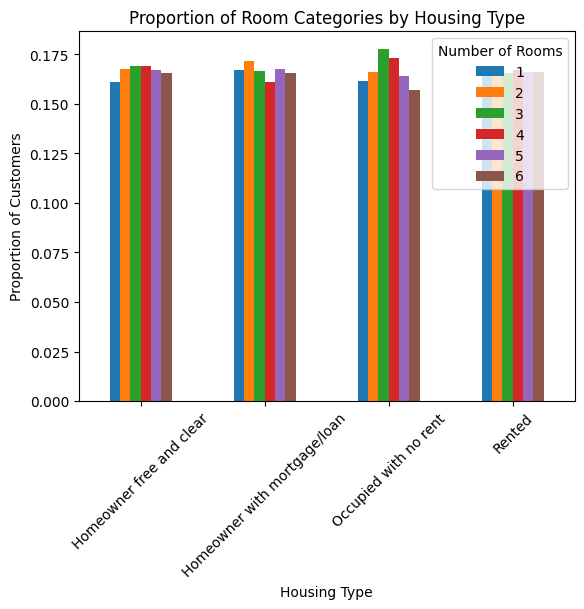

```python
# check if the number of rooms corresponds to the housing type
rooms_by_housing = customer.groupby('housing_type')['rooms'].value_counts(normalize=True)
rooms_by_housing = rooms_by_housing.unstack(fill_value=0)
rooms_by_housing.plot(kind='bar', stacked=False)
plt.title('Proportion of Room Categories by Housing Type')
plt.xlabel('Housing Type')
plt.ylabel('Proportion of Customers')
plt.xticks(rotation=45)
plt.legend(title='Number of Rooms')
plt.show()
```

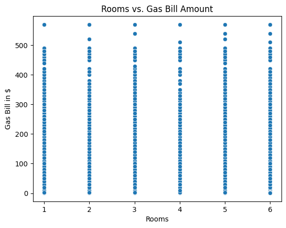

```python
sns.scatterplot(x='rooms', y='gas_usage', data=customer)
plt.title('Rooms vs. Gas Bill Amount')
plt.xlabel('Rooms')
plt.ylabel('Gas Bill in $')
plt.show()
```

Currently, we have three variables about the housing situation. One is housing type, one the monthly gas bill amount, and the other one is number of rooms. Therefore, we wanted to check a possible correlation to prevent collinearity issues in the model building process. The plots do, however, show that there are no strong correlations between the variables.

Now that we have explored our model input variables in depth, we will analyse the relationship between the input variables and our target variable health insurance. First, we will plot how many uninsured customers there are at every age.

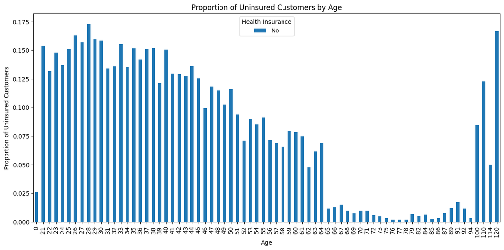

```python
# Calculate insurance rate for each age
age_insurance_rate = customer.groupby('age')['health_ins'].mean().sort_values()
age_vs_health = customer.groupby('age')['health_ins'].value_counts(normalize=True)

# Filter for uninsured customers
uninsured_data = age_vs_health[age_vs_health.index.get_level_values('health_ins') == False]

# Check available ages in uninsured_data
available_ages = uninsured_data.index.get_level_values('age').unique()

# Plot the ages with the respective rate of uninsured individuals
uninsured_data.unstack().loc[available_ages].plot(kind='bar', figsize=(12, 6))
plt.title('Proportion of Uninsured Customers by Age')
plt.xlabel('Age')
plt.ylabel('Proportion of Uninsured Customers')
plt.legend(title='Health Insurance', labels=["No"])
plt.xticks(rotation=90)
plt.tight_layout()
plt.show()
```

We can see a strong downward trend with higher age. The probability of a customer being uninsured is decreasing as the customer gets older. A possible reason is that, as people age, they become more aware of the importance of health coverage, have more medical needs, and strive for more stability. Moreover, individuals become eligible for the government-sponsored federal health-insurance program Medicare at age 65, significantly increasing insurance coverage among this age group (USA Gov, n.d.). This could explain the dip of the uninsurance rate at 65. The fact that this strong trend is broken by the observations with customers over 100 reinforces the assumption that those observations are errors and should be excluded in the Data Preprocessing.

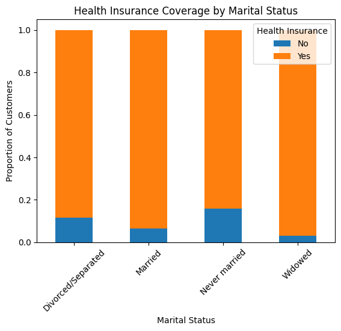

```python
marriage_vs_health = customer.groupby('marital_status')["health_ins"].value_counts(normalize=True)
marriage_vs_health.unstack().plot(kind='bar', stacked=True)
plt.title('Health Insurance Coverage by Marital Status')
plt.xlabel('Marital Status')
plt.ylabel('Proportion of Customers')
plt.xticks(rotation=45)  # Rotate x-axis labels for better readability
plt.legend(title='Health Insurance', labels=['No', 'Yes'])  # Customize legend
plt.show()
```

The proportion of uninsured individuals is higher among those who have never been married. This could be attributed to the lower income generated by a single individual than by a married couple, there are expenses which decrease when split among people, e.g. housing and food cost. Moreover, married individuals tend to have a more stable lifestyle, which is likely connected to a certain risk-aversion and the priorization of health insurance to protect their families. In contrast, those who have never married may be less concerned about health risks and prioritize other expenses.

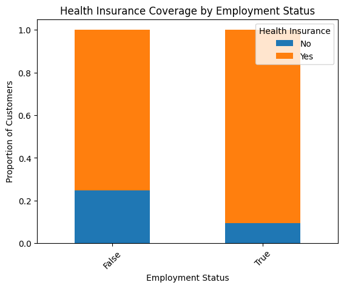

```
Median Income:
Employed:  39600.0
Unemployed:  6000.0
```

```python
employment_vs_health = customer.groupby('is_employed')["health_ins"].value_counts(normalize=True)
employment_vs_health.unstack().plot(kind='bar', stacked=True)
plt.title('Health Insurance Coverage by Employment Status')
plt.xlabel('Employment Status')
plt.ylabel('Proportion of Customers')
plt.xticks(rotation=45)
plt.legend(title='Health Insurance', labels=['No', 'Yes'])
plt.show()

employment_vs_income = customer.groupby('is_employed')['income'].median()
print("Median Income:")
print("Employed: ", round(employment_vs_income[True],2))
print("Unemployed: ", round(employment_vs_income[False],2))
```

The data indicates that a significant proportion of individuals lacking health insurance are unemployed. Financial constraints associated with unemployment may be a primary factor contributing to this notable disparity. Previous statistics have shown that approximately half of unemployed individuals have an income below 6000, impacting the ability to afford health insurance.

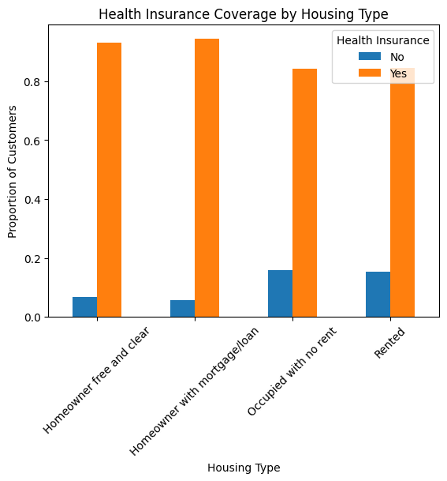

```python
employment_vs_health = customer.groupby('housing_type')["health_ins"].value_counts(normalize=True)
employment_vs_health.unstack().plot(kind='bar', stacked=False)
plt.title('Health Insurance Coverage by Housing Type')
plt.xlabel('Housing Type')
plt.ylabel('Proportion of Customers')
plt.xticks(rotation=45)
plt.legend(title='Health Insurance', labels=['No', 'Yes'])
plt.show()
```

```python
housing_vs_income = customer.groupby('housing_type')['income'].median()
housing_cat = customer['housing_type'].unique()

for cat in housing_cat:
  # Check if cat is not NaN before proceeding
  if pd.notna(cat):
    print(f"Median Income for {cat}: ", housing_vs_income[str(cat)])
```

```
Median Income for Homeowner free and clear:  24500.0
Median Income for Rented:  20800.0
Median Income for Homeowner with mortgage/loan:  36300.0
Median Income for Occupied with no rent:  17150.0
```

Homeownership, whether with or without a mortgage or loan, is often associated with greater financial stability and higher income. This is because homeownership is a significant financial investment, and those who own their homes are more likely to have accumulated wealth over time. Therefore, individuals who own their homes are more likely to be able to afford health insurance premiums. Conversely, those who rent or live in social housing, which often comes with lower costs, may experience financial instability, which could contribute to higher rates of non-insurance. Moreover, owning a house is probable to be related to the raising of a family, which leads to a higher need of stability and safety as ensured by an insurance.

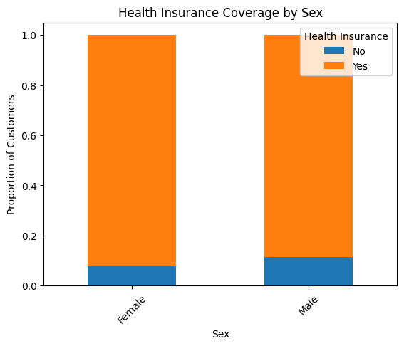

```python
sex_vs_health = customer.groupby('sex')["health_ins"].value_counts(normalize=True)
sex_vs_health.unstack().plot(kind='bar', stacked=True)
plt.title('Health Insurance Coverage by Sex')
plt.xlabel('Sex')
plt.ylabel('Proportion of Customers')
plt.xticks(rotation=45)
plt.legend(title='Health Insurance', labels=['No', 'Yes'])
plt.show()
```

```python
# Printing the results for income obtained in a previous analysis of
# distribution of income by sex gender
print("Incomes:")
print("Male: ", round(sex_income["Male"]))
print("Female: ", round(sex_income["Female"]))
```

```
Incomes:
Male:  34600
Female:  20000
```

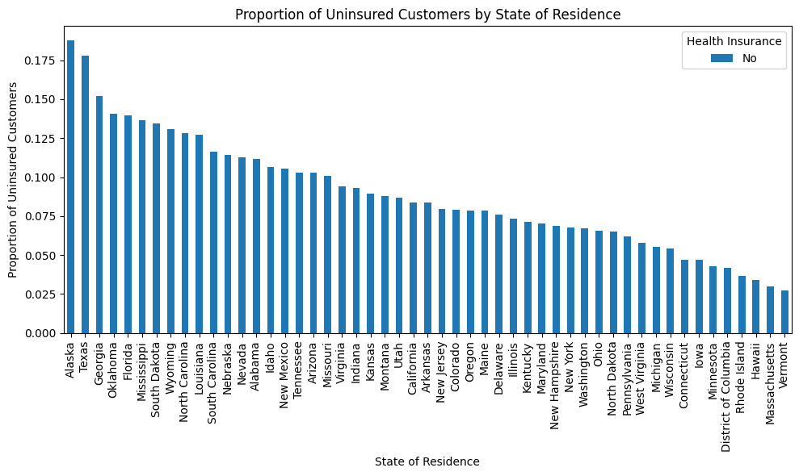

```python
# Calculate insurance rate for each state
state_insurance_rate = customer.groupby('state_of_res')['health_ins'].mean().sort_values()

# Create a grouped bar chart with sorted states
state_vs_health = customer.groupby('state_of_res')["health_ins"].value_counts(normalize=True)

# Filter for uninsured customers
uninsured_data = state_vs_health[state_vs_health.index.get_level_values('health_ins') == False]

# Plot only the uninsured data
uninsured_data.unstack().loc[state_insurance_rate.index].plot(kind='bar', figsize=(10, 6))

# Customize the plot
plt.title('Proportion of Uninsured Customers by State of Residence')
plt.xlabel('State of Residence')
plt.ylabel('Proportion of Uninsured Customers')
plt.legend(title='Health Insurance', labels = ["No"])
plt.xticks(rotation=90)
plt.tight_layout()
plt.show()
```

```python
# USA states data for iterative plotting schemes
us_states = gpd.read_file('https://raw.githubusercontent.com/PublicaMundi/MappingAPI/master/data/geojson/us-states.json')
```

```python
# Plot the USA map with the Insured Customers

# Rename the columns of the Dataset Series
state_insurance_rate_df = state_insurance_rate.reset_index()
state_insurance_rate_df.rename(columns={'state_of_res': 'state', 'health_ins': 'insurance_rate'}, inplace=True)

fig = px.choropleth(
    state_insurance_rate_df,
    geojson=us_states,
    locations='state',
    featureidkey="properties.name",
    color='insurance_rate',
    color_continuous_scale="OrRd",
    scope="usa",
    title="Insured Customers by USA state",
    hover_name='state',
    hover_data={'insurance_rate': True},
    labels={'insurance_rate': 'Proportion of Insured Customers'}
)

fig.update_geos(fitbounds="locations", visible=False)
fig.update_layout()
fig.show()
```

[interactive chart not shown]

We can see strong differences in the amount of uninsured individuals depending on the state of residence. Alaska and Texas have an exceptionally high proportion of uninsured residents. We will check if that might be related to the income levels of the states.

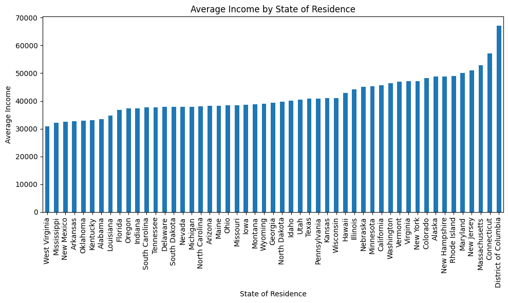

```python
# Create a variable that contains the average income from each US state
state_income = customer.groupby('state_of_res')['income'].mean().sort_values()
state_income.plot(kind='bar', figsize=(10, 6))
plt.title('Average Income by State of Residence')
plt.xlabel('State of Residence')
plt.ylabel('Average Income')
plt.xticks(rotation=90)
plt.tight_layout()
plt.show()
```

```python
# Plot the USA map with the Average Income

# Rename the columns of the Dataset Series
state_income_df = state_income.reset_index()
state_income_df.rename(columns={'state_of_res': 'state', 'income': 'avg_income'}, inplace=True)

fig = px.choropleth(
    state_income_df,
    geojson=us_states,
    locations='state',
    featureidkey="properties.name",
    color='avg_income',
    color_continuous_scale="OrRd",
    scope="usa",
    title="Average Income by USA state",
    hover_name='state',
    hover_data={'avg_income': True},
    labels={'avg_income': 'US Dollars'}
)
fig.update_geos(fitbounds="locations", visible=False)
fig.update_layout()
fig.show()
```

[interactive chart not shown]

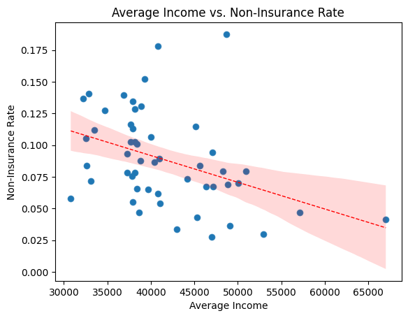

```python
state_data = pd.merge(state_income, uninsured_data, on='state_of_res')
state_data.rename(columns={'income':'avg_income', 'health_ins': 'insurance_rate'}, inplace=True)

sns.scatterplot(data=state_data, x='avg_income', y='proportion')
sns.regplot(x='avg_income', y='proportion', data=state_data,
            line_kws={'linestyle': '--', 'color': 'red', 'linewidth': 1})
plt.title('Average Income vs. Non-Insurance Rate')
plt.xlabel('Average Income')
plt.ylabel('Non-Insurance Rate')
plt.show()
```

```python
correlation_coef = state_data.corr('pearson')
print(correlation_coef)
```

```
            avg_income  proportion
avg_income    1.000000   -0.395376
proportion   -0.395376    1.000000
```

Lastly, we will display heatmaps to show the correlations among all our variables.

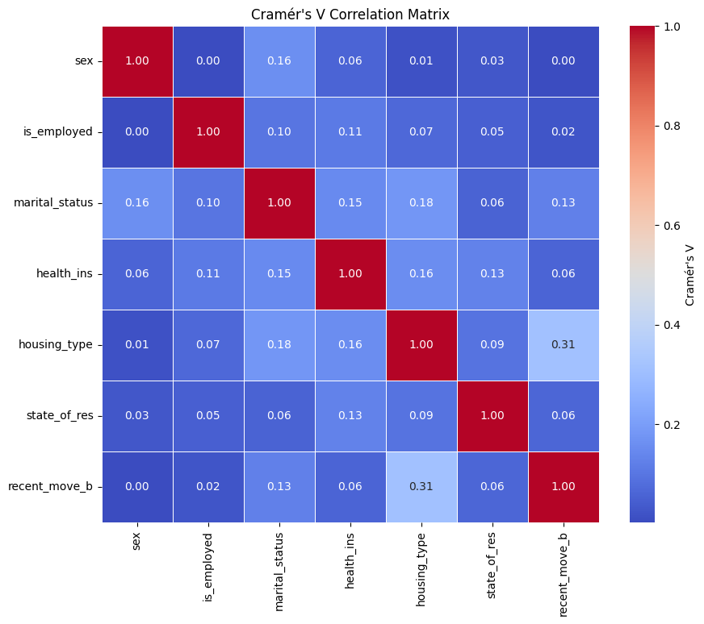

```python
# Function to calculate Cramér's V
def cramers_v(x, y):
    confusion_matrix = pd.crosstab(x, y)
    chi2 = chi2_contingency(confusion_matrix)[0]
    n = confusion_matrix.sum().sum()
    phi2 = chi2 / n
    r, k = confusion_matrix.shape
    return np.sqrt(phi2 / min(k - 1, r - 1))

# Categorical columns to analyze
categorical_cols = ['sex', 'is_employed', 'marital_status', 'health_ins',
                    'housing_type', 'state_of_res',
                    'recent_move_b']

# Creating a Cramér's V matrix
v_matrix = pd.DataFrame(index=categorical_cols, columns=categorical_cols)

for i in range(len(categorical_cols)):
    for j in range(len(categorical_cols)):
        if i == j:
            v_matrix.iat[i, j] = 1.0  # Perfect correlation with itself
        else:
            v_matrix.iat[i, j] = cramers_v(customer[categorical_cols[i]], customer[categorical_cols[j]])

# Plotting the heatmap
plt.figure(figsize=(10, 8))
sns.heatmap(v_matrix.astype(float), annot=True, cmap='coolwarm', fmt=".2f",
            cbar_kws={'label': 'Cramér\'s V'},
            square=True, linewidths=0.5)
plt.title('Cramér\'s V Correlation Matrix')
plt.show()
```

The matrix shows that marital as well as housing status, and state of residence have the highest correlations with health insurance coverage. Among those variables, the most significant correlation is between marital status and housing type. This reinforces our earlier assumption that the housing type is influenced by the family situation of an individual. Nonetheless, also employment status has a correlation of 0.11 with health insurance. The correlation matrix, therefore, tells us that the variables in our dataset are relevant for the target variable. Furthermore, we will probably not have multicollinearity issues. The highest correlation is between housing type and the boolean value of a recent move with 0.31. This is not considered high enough to cause collinearity issues.

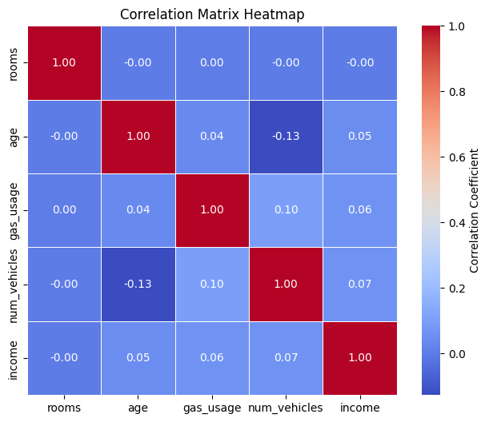

```python
# Define the columns you want to include in the correlation matrix
columns_to_include = ['rooms', 'age', 'gas_usage','num_vehicles', 'income']

# Create a filtered DataFrame with only the specified columns
df_filtered = customer[columns_to_include]

# Now you can calculate the correlation matrix for the filtered DataFrame
correlation_matrix = df_filtered.corr()

# Plotting the heatmap
plt.figure(figsize=(8, 6))
sns.heatmap(correlation_matrix, annot=True, cmap='coolwarm', fmt=".2f",
            cbar_kws={'label': 'Correlation Coefficient'},
            square=True, linewidths=0.5)
plt.title('Correlation Matrix Heatmap')
plt.show()
```

The correlation matrix of the numerical variables shows no significant correlations, which reinforces that we will not encounter collinearity issues. The highest correlation is a negative correlation between age and number of vehicles with -0.13. This might be caused by the fact that older individuals are in some cases not able to drive anymore.

# **Data Preparation**

In the following we will conduct all of the necessary preprocessing steps which were identified in the prior section. For further information and reasoning for the processing steps, please refer to the prior section.

```python
# Drop the uninformational columns
customer = customer.drop(columns=['Unnamed: 0', 'code_column'])
customer_test_masked = customer_test_masked.drop(columns=['Unnamed: 0', 'code_column'])

# Set the 'custid' column as the index-column for the dataset
customer = customer.set_index([pd.Series(range(1, len(customer) + 1)),'custid'])
customer_test_masked = customer_test_masked.set_index([pd.Series(range(1, len(customer_test_masked) + 1)),'custid'])
```

```python
# Drop the rows with NA in recent_move_b
customer = customer.dropna(subset=['recent_move_b'])

# Imputation for "recent_move_b" for test_masked
customer_test_masked['recent_move_b'] = customer_test_masked['recent_move_b'].fillna(False)
customer.isnull().sum()
```

The assumption that the NAs in the categories except for employment status were the same was correct - we have removed all of them by removing the NAs in recent_move_b.

```python
# change employment status of NAs in is_employed to False
customer['is_employed'] = customer['is_employed'].fillna(False)
customer_test_masked['is_employed'] = customer_test_masked['is_employed'].fillna(False)

# drop the cases with net negative income
customer.drop(customer[customer['income'] < 0].index, inplace=True)

# imputing missing values according to the median for negative income
median_income_test = customer_test_masked[customer_test_masked['income'] >= 0]['income'].median()
customer_test_masked.loc[customer_test_masked['income'] < 0, 'income'] = median_income_test

# drop the rows in which age equals 0 or above 100
indexes_newborns = customer[(customer['age'] == 0)].index
indexes_elder = customer[customer['age'] > 99].index
customer.drop(indexes_newborns, inplace=True)
customer.drop(indexes_elder, inplace=True)

median_age = customer_test_masked[(customer_test_masked['age'] > 0) & (customer_test_masked['age'] <= 99)]['age'].median()
customer_test_masked.loc[(customer_test_masked['age'] == 0) | (customer_test_masked['age'] > 99), 'age'] = median_age
```

```python
# show values for the categorical values to ensure uniformity and cleanness
for column in customer.select_dtypes(include=['object', 'category','bool']):
  print(f"Unique values for {column}:")
  print(customer[column].unique())
  print("\n")
```

```python
# Change to the appropriate boolean values in 'recent_move_b' parameter
customer['recent_move_b'] = customer['recent_move_b'].replace({'T': True, 'F': False})
customer_test_masked['recent_move_b'] = customer_test_masked['recent_move_b'].replace({'T': True, 'F': False})
```

The nominal values should be encoded and the boolean values converted to numerical values to prevent errors in the model building process. We will use One Hot Encoding to encode all of our nominal columns except the residence state. The alternative would be using a Label Encoder. This does, however, carry the risk of the values being interpreted as numerical and given an ordinal order by the models. The disadvantage of One Hot Encoding is that columns with a high number of possible values, such as residence state, will produce a large amount of additional columns, resulting in higher running time and computational complexity. Therefore, we decided for Label Encoding for the residence state column.

```python
# Use One Hot Encoding for the nominal columns except for residence state
columns_to_encode = ["marital_status", "housing_type", "sex"]

for column in columns_to_encode:
    dummies = pd.get_dummies(customer[column], drop_first=True, prefix=column)
    customer = pd.concat([customer, dummies], axis=1)
    customer = customer.drop(columns=[column])

for column in columns_to_encode:
    dummies = pd.get_dummies(customer_test_masked[column], drop_first=True, prefix=column)
    customer_test_masked = pd.concat([customer_test_masked, dummies], axis=1)
    customer_test_masked = customer_test_masked.drop(columns=[column])

# Use Label Encoding for residence state
from sklearn.preprocessing import LabelEncoder
enc = LabelEncoder()
customer["state_of_res"] = enc.fit_transform(customer["state_of_res"])
encoded_labels = enc.classes_
encoded_values = dict(enumerate(encoded_labels))

customer_test_masked["state_of_res"] = enc.fit_transform(customer_test_masked["state_of_res"])

# Display encoded labels for future reference
encoded_values
```

When looking at the distribution of income in the section above, we noted a markedly skewed distribution. Therefore, we will perform a log-transformation of the income. The application of a log-transformation is justified due to the considerable discrepancy between the range of income values and the notable difference between the mean and median for this parameter. The discrepancy is indicative of the skewed distribution of income values. A log-transformation of this parameter, taking into account the discontinuity issues arising from income values approaching or equal to zero, should, in practice, approximate the median and mean values to a common value. This facilitates subsequent analysis, as the distribution of income values becomes more symmetrical. It is also important to note that some machine learning models exploit symmetries inherent in data, so that they will perform better with the log-transformed income.

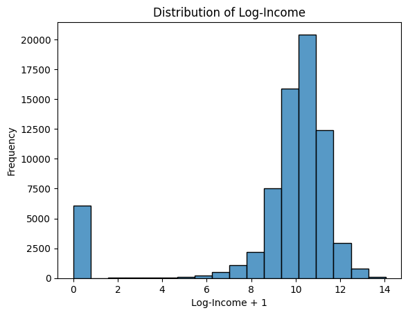

```python
# Histogram for the Log-transformation of income values
sns.histplot(np.log(customer['income'] + 1), bins=18)
plt.title('Distribution of Log-Income')
plt.xlabel('Log-Income + 1')
plt.ylabel('Frequency')
plt.show()
```

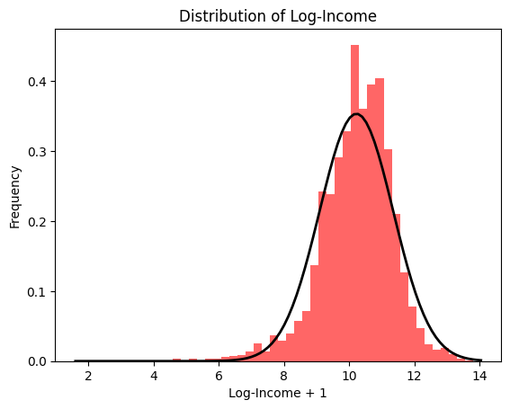

```python
# Visual inspection to determine if the income different from zero follows normality
def gaussian(mu, sigma, x):
    return 1/(sigma * np.sqrt(2 * np.pi)) * np.exp(-(x - mu)**2 / (2 * sigma**2))

customer_income_log = np.log(customer["income"] + 1)
customer_income_trunc = customer_income_log[customer_income_log > 1]

mu = customer_income_trunc.mean()
std = customer_income_trunc.std()

data_test = np.linspace(customer_income_trunc.min(), customer_income_trunc.max(), 100)
plt.hist(customer_income_trunc, bins=50, density=True, alpha=0.6, color='r')
plt.plot(data_test, gaussian(mu, std, data_test), 'k', linewidth=2)
plt.title('Distribution of Log-Income')
plt.xlabel('Log-Income + 1')
plt.ylabel('Frequency')
plt.show()
```

The plots show that the distribution of income values is in close approximation to a normal distribution. The distribution of these income values suggests the existence of a symmetric distribution. To sum up, the data speaks in favor of an application of a log-transformation.

```python
# Log-transformation for customer['income']
customer['income'] = customer_income_log
customer_test_masked['income'] = np.log(customer_test_masked['income'] + 1)
```

We can see that we also have a high number of individuals with an income of 0 - this is the case when their earnings are equal to or higher than their expenses. It is possible that there is a significant difference between people who have any income and those who do not. This difference might be more predictive than the correlations we can see within the range of income. Therefore, as a means of feature, engineering, we will create a new, binary variable which contains information about whether a person has any income.

```python
# Create feature containing if a person has income or not
customer['income_y_n'] = customer['income'] > 0
customer_test_masked['income_y_n'] = customer_test_masked['income'] > 0
```

As a next step, we will standardize all of the other numerical columns. Standardizing numerical columns is crucial in predictive modeling to ensure that features contribute equally to the model. When features are measured on different scales (e.g., the gas bill amount in $ versus age in years), models can assign disproportionate importance to features with larger magnitudes. Standardization transforms features into a common scale, preventing this bias. Additionally, some of the models we will implement operate in a linear space, wherefore standardized data will improve their performance and reliability.

```python
# separate the numerical features to be standardized
features_to_standardize = customer[['gas_usage', 'income',"num_vehicles","age","rooms"]]
features_to_standardize_test = customer_test_masked[['gas_usage','income',"num_vehicles","age","rooms"]]

# create a StandardScaler object
scaler = StandardScaler()

# fit and transform the selected features
standardized_features = scaler.fit_transform(features_to_standardize)
standardized_features_test = scaler.fit_transform(features_to_standardize_test)

# replace the original columns with the standardized ones
customer[features_to_standardize.columns] = standardized_features
customer_test_masked[features_to_standardize_test.columns] = standardized_features_test
```

Polynomial features can improve the performance of machine learning models by capturing non-linear relationships between input features and the target variable that linear models cannot. By expanding the feature space to include higher-order combinations of input variables, models can approximate more complex patterns in the data. We could see polynomial features improved model performance in our case, wherefore we generated polynomial features of order 2 for all of our numerical variables.

```python
# Select the numeric features from the customer data
customer_numeric = customer.select_dtypes(include=['float64'])
customer_test_masked_numeric = customer_test_masked.select_dtypes(include=['float64'])

# Drop the 'health_ins' column from customer_test_masked
customer_test_masked_numeric_X = customer_test_masked_numeric.drop(columns=['health_ins'])
customer_test_masked_X = customer_test_masked.drop(columns=['health_ins'])

# Impute missing values with the mean before applying PolynomialFeatures
imputer = SimpleImputer(strategy='median')

customer_test_masked_X = pd.DataFrame(imputer.fit_transform(customer_test_masked_X),
        columns=customer_test_masked_X.columns, index=customer_test_masked_X.index)

customer_test_masked_numeric_X = pd.DataFrame(imputer.fit_transform(customer_test_masked_numeric_X),
        columns=customer_test_masked_numeric_X.columns, index=customer_test_masked_numeric_X.index)

# Create Polynomial features with degree at most 2
poly_2 = PolynomialFeatures(degree=2, include_bias=False)
poly_features_2 = poly_2.fit_transform(customer_numeric)
poly_features_2_test = poly_2.fit_transform(customer_test_masked_numeric_X)

# Convert the polynomial features to a DataFrame
poly_features_2 = pd.DataFrame(poly_features_2, columns=poly_2.get_feature_names_out(customer_numeric.columns), index=customer.index)
poly_features_2_test = pd.DataFrame(poly_features_2_test, columns=poly_2.get_feature_names_out(customer_test_masked_numeric_X.columns), index=customer_test_masked_numeric_X.index)

# Concatenate the new features to the customer data
customer = pd.concat([customer, poly_features_2], axis=1)
customer_test_masked = pd.concat([customer_test_masked_X, poly_features_2_test], axis=1)

# Drop the extra index column that gets added, if any
customer = customer.drop(columns=['index'], errors='ignore')
customer_test_masked = customer_test_masked.drop(columns=['index'], errors='ignore')  #errors='ignore' will prevent error if column doesn't exist
```

The data is clean and adequately processed now. We can now start building our models.

# **Modeling with imbalanced data**

To be able to build predictive models, we first have to split our dataset into training and validation subsets. Then, we will proceed to build models of different types and finetune their parameters. To evaluate the performance of our models, we will use cross-validation based on our training data in the finetuning process. Finally, we will compare the performance of the optimized models based on the validation dataset and decide for a final model. The final evaluation will be made according to the F1 score.

```python
X = customer.drop(columns=['health_ins'])
y = customer['health_ins']

# Shuffle the data
X, y = shuffle(X, y, random_state=42)

# Split the data into training and validation sets
X_train, X_valid, y_train, y_valid = train_test_split(X, y, test_size=0.3, random_state=42)
```

## Feature Importance

Before building the first model, we will use the SelectKBest method with the mutual_info_classif scoring function to evaluate feature importance in predicting whether a person has health insurance. The function measures the mutual information between each feature and the target variable health insurance to identify features that contribute most to predicting health insurance coverage. This method provides valuable insight, as it allows us to better understand how our models work and what will be their focus.

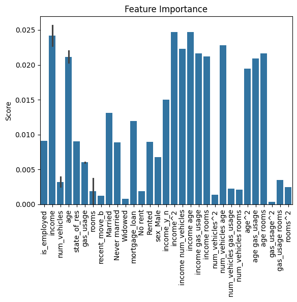

```python
fs = SelectKBest(score_func=mutual_info_classif, k='all')
fs.fit(X_train, y_train)
X_train_fs = fs.transform(X_train)

# Create new label titles for better visualization of plots
X_train_col_new = list(X_train.columns.copy())

for i,label in enumerate(X_train.columns):
    if 'marital_status_' in label:
        X_train_col_new[i] = label.removeprefix('marital_status_')
    elif 'housing_type_' in label:
        X_train_col_new[i] = label.removeprefix('housing_type_')

X_train_col_new[11] = 'mortgage_loan'
X_train_col_new[12] = 'No rent'

sns.barplot(x=X_train_col_new, y=fs.scores_)
plt.xticks(rotation=90)
plt.title('Feature Importance')
plt.ylabel('Score')
plt.show()
```

Income and age stand out with the highest scores, indicating they are the strongest predictors in this dataset. Income is naturally significant, as individuals with higher earnings are more frequently able to afford health insurance, either privately or through employer-sponsored plans. Age is also highly relevant, as insurance needs and options vary considerably across age groups. Older individuals, for instance, are more likely to require healthcare and may have access to age-specific programs like Medicare, which increases the likelihood of coverage.

Other features, such as Rented and Marital Status (Never Married), have moderate scores. Renting may reflect a person’s financial stability and indirectly influence their ability to maintain insurance. Those who rent may have fewer assets than homeowners, which could affect their access to health coverage. Moreover, single individuals are less likely to benefit from spousal health plans, relying more on individual coverage options. Similarly, the Number of Vehicles owned can be a loose indicator of financial resources and lifestyle, which may influence the ability to afford insurance, though it is not as directly impactful as income or age.

In contrast, features like Gas Usage and Number of Rooms have relatively low importance. The feature importance scores are in line with our findings from the section "Data Understanding".

## Logistic Regression

The first model we will build is a logistic regression. We will finetune our model by changing the different parameters, starting with the solver algorithm.

```python
# Set up the default model to check which evaluation metrics to focus our finetuning process on
log_reg = LogisticRegression()
log_reg.fit(X_train, y_train)
log_reg_preds_train = cross_val_predict(log_reg, X_train, y_train, cv=5)

print(classification_report(y_train, log_reg_preds_train))
```

```
              precision    recall  f1-score   support

       False       0.41      0.01      0.03      4414
        True       0.91      1.00      0.95     44861

    accuracy                           0.91     49275
   macro avg       0.66      0.51      0.49     49275
weighted avg       0.87      0.91      0.87     49275
```

We can see that there is an exceptionally low recall for the uninsured cases. Our model manages to detect all people with health insurance, but fails to identify the people without health insurance. Considering that our focus is on finding clients without health insurance, this is a serious problem. It is probable that the low recall score is caused by the dataset's imbalance. Considering that there are a lot fewer instances of people without insurance, the model may focus on predicting the majority class (those with insurance). Other possible reasons are that the key features influencing the likelihood of being uninsured are missing or poorly represented in the data or insufficient data preprocessing. Given that we have preprocessed the data very cautiously and the richness of information in our dataset, we deem these reasons improbable.

Before tuning our model, we analyze the group of uninsured people not correctly classified by our model to see if there is any pattern.

```python
# False positives: where actual = 0 and predicted = 1
false_positive_mask = (y_train == 0) & (log_reg_preds_train == 1)
false_positives = X_train[false_positive_mask]

# General group (entire validation dataset)
true_negative_mask = (y_train == 0) & (log_reg_preds_train == 0)
true_negatives = X_train[true_negative_mask]

# Calculate descriptive statistics
false_positives_stats = false_positives.describe()
true_negatives_stats = true_negatives.describe()

print("Descriptive Statistics for False Positives:")
print(false_positives_stats)

print("\nDescriptive Statistics for True Negatives:")
print(true_negatives_stats)
```

[output not shown]

```python
# For nominal features, calculate value counts or proportions for each group
nominal_features = [
    'is_employed',
    'recent_move_b',
    'marital_status_Married',
    'marital_status_Never married',
    'marital_status_Widowed',
    'housing_type_Homeowner with mortgage/loan',
    'housing_type_Occupied with no rent',
    'housing_type_Rented',
    'sex_Male',
    'income_y_n'
]

# Overview of false positives
print("Overview of False Positives:")
for feature in nominal_features:
    print(f"\n{feature} in False Positives:")
    print(false_positives[feature].value_counts(normalize=True))  # normalize=True gives proportions

# Overview of true negatives
print("\nOverview of True Negatives:")
for feature in nominal_features:
    print(f"\n{feature} in True Negatives:")
    print(true_negatives[feature].value_counts(normalize=True))
```

[output not shown]

- higher proportion of unemployed
- significantly lower income or no income at all
- lower proportion of married individuals
- higher proportion of renters/lower proportion of home owners
- less vehicles and lower gas bills

In conclusion, it seems like the model can successfully identify the lowest social group without health insurance, but struggles as soon it has to identify non-extreme cases. We will attempt to solve this problem by finetuning our model to increase recall.

```python
# Try different solving algorithms for the optimization problem
solvers = ["newton-cg", "lbfgs", "liblinear", "sag", "saga"]
train_recall = {}

for solver_name in solvers:

    log_reg = LogisticRegression(solver=solver_name)
    log_reg_preds_train = cross_val_predict(log_reg, X_train, y_train, cv=4)

    # Calculate the recall score
    train_recall[solver_name] = recall_score(y_train, log_reg_preds_train, pos_label=0)

print("Train Recall: ",sorted(train_recall.items(), key = lambda x: x[1], reverse = True))
```

```
Train Recall:  [('lbfgs', 0.014952424105120073), ('sag', 0.014499320344358859), ('saga', 0.013819664703217037), ('newton-cg', 0.013140009062075216), ('liblinear', 0.013140009062075216)]
```

We can clearly see that the "lbfgs" algorithm performs best, when looking at the recall. Therefore, we will proceed with this algorithm for our final model.

In the following, we will use regularization to enhance model performance, specifically, we will try the L2 regularization technique. L1 and L2 regularization are techniques used to prevent overfitting in machine learning models by adding a penalty to the loss function based on the size of the coefficients. L1 regularization, or Lasso, encourages sparsity by penalizing the absolute values of the coefficients, which can lead to some features being completely excluded from the model. In contrast, L2 regularization, or Ridge, penalizes the squared values of the coefficients, resulting in smaller but non-zero coefficients for all features. Considering that the "lbfgs" algorithm does not work with L1 regularization, we will just try L2 regularization and check if that increases the model performance without regularization.

```python
# Try regularization
log_reg = LogisticRegression(solver="lbfgs", penalty="l2")
log_reg_preds_train = cross_val_predict(log_reg, X_train, y_train, cv=5)

# Calculate recall score
train_recall = recall_score(y_train, log_reg_preds_train, pos_label=0)
print(train_recall)
```

```
0.013366560942455823
```

The L2 penalty even slightly decreased our recall score. As a next step, we will maintain L2 regularization and finetune the parameter C to see if that increases our performance. The values of C corresponds to the strength or regularization. Small values mean strong regularization, wherefore model will penalize large coefficients more aggressively. This results in smaller coefficient values, which helps prevent overfitting by keeping the model simpler. Large values of C correspond to weaker regularization, meaning that the penalty on large coefficients is reduced. The model is allowed to assign larger values to the coefficients, which may lead to overfitting if the data is noisy.

```python
c_values = [0.1, 0.3, 0.5, 0.7, 1.0, 1.2, 1.5]
train_recall = {}

for c_float in c_values:

    log_reg = LogisticRegression(solver="lbfgs", penalty="l2",C=c_float)
    log_reg_preds_train = cross_val_predict(log_reg, X_train, y_train, cv=4)

    # Calculate the recall score
    train_recall[c_float] = recall_score(y_train, log_reg_preds_train, pos_label=0)

print("Train Recall: ",sorted(train_recall.items(), key = lambda x: x[1], reverse = True))
```

```
Train Recall:  [(1.0, 0.014952424105120073), (1.2, 0.013819664703217037), (0.3, 0.01359311282283643), (0.5, 0.01359311282283643), (0.7, 0.01359311282283643), (1.5, 0.013140009062075216), (0.1, 0.011327594019030359)]
```

The recall scores are the same for the unregularized model and regularization with C = 1.0. Therefore, we will build our final model with regularization and C = 1.0. The advantage of building the final model with regularization is that regularization simplifies the model and prevents overfitting. This is why it is likely that the regularized model generalizes better to unseen data.

```python
# Final Model
log_reg = LogisticRegression(solver="lbfgs", penalty="l2", C = 1.0)

log_reg_preds_train = cross_val_predict(log_reg, X_train, y_train, cv=5)


# Print the classification report
print(classification_report(y_train, log_reg_preds_train))
```

```
              precision    recall  f1-score   support

       False       0.41      0.01      0.03      4414
        True       0.91      1.00      0.95     44861

    accuracy                           0.91     49275
   macro avg       0.66      0.51      0.49     49275
weighted avg       0.87      0.91      0.87     49275
```

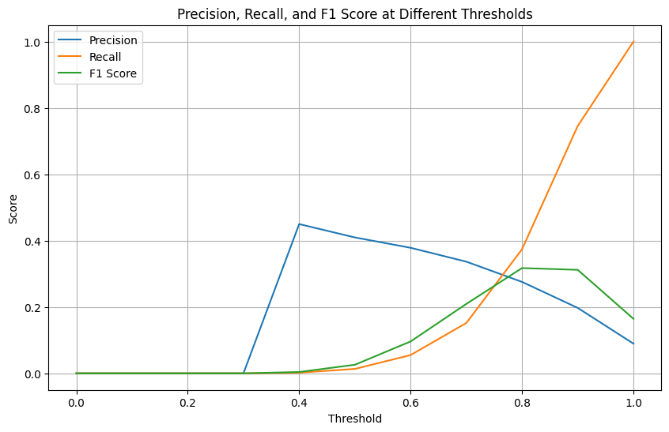

```python
# Get predicted probabilities for both classes
log_reg_probs_train = cross_val_predict(log_reg, X_train, y_train, cv=5, method='predict_proba')

# Get predicted probabilities for the positive class (1)
y_probs = log_reg_probs_train[:, 1]

def evaluate_threshold(threshold, y_true, y_probs):
    y_pred = (y_probs >= threshold).astype(int)
    precision = precision_score(y_true, y_pred, pos_label=0)
    recall = recall_score(y_true, y_pred, pos_label=0)
    f1 = f1_score(y_true, y_pred, pos_label=0)
    return precision, recall, f1

# Define thresholds to test
thresholds = np.arange(0.0, 1.1, 0.1)
metrics = {'threshold': [], 'precision': [], 'recall': [], 'f1': []}

for threshold in thresholds:
    precision, recall, f1 = evaluate_threshold(threshold, y_train, y_probs)
    metrics['threshold'].append(threshold)
    metrics['precision'].append(precision)
    metrics['recall'].append(recall)
    metrics['f1'].append(f1)

# Plot the metrics
plt.figure(figsize=(10, 6))
plt.plot(metrics['threshold'], metrics['precision'], label='Precision')
plt.plot(metrics['threshold'], metrics['recall'], label='Recall')
plt.plot(metrics['threshold'], metrics['f1'], label='F1 Score')
plt.xlabel('Threshold')
plt.ylabel('Score')
plt.title('Precision, Recall, and F1 Score at Different Thresholds')
plt.legend()
plt.grid()
plt.show()
```

The plot shows that there is a strong trade-off between precision and recall in our case. To decide which metric to prioritize, we should consider the business background of our problem. Precision tells us how many of the identified uninsured clients are actually uninsured. A high precision score means that all of the marketing efforts directed towards the identified clients are worth it and no budget is wasted by advertising health insurance to clients who are already insured. Vice versa, a low precision score means that the company makes many marketing efforts without chances of success. Recall tells us how many of the uninsured clients are identified by the model. A high recall means that the company reaches out to most of the uninsured clients, thereby maximizing the possible profit to be made with this client group. A low recall score means that the company fails to reach out to many of their uninsured clients, thereby failing to making a profit of them. In this case, the company faces high opportunity cost. Considering that the cost of targeted marketing is probably rather low (e.g. an e-mail or phone call) in comparison to the value of a potential new health insurance client, we should prioritize recall to maximize company profits. The F1 score is the harmonic mean of recall and precision and will be the ultimate measure of our model performance.

```
Classification Report for Training Dataset with Threshold = 0.9:
              precision    recall  f1-score   support

       False       0.20      0.75      0.31      4414
        True       0.97      0.70      0.81     44861

    accuracy                           0.71     49275
   macro avg       0.58      0.72      0.56     49275
weighted avg       0.90      0.71      0.77     49275

Classification Report for Validation Dataset with Threshold = 0.9:
              precision    recall  f1-score   support

       False       0.21      0.75      0.33      1983
        True       0.97      0.71      0.82     19136

    accuracy                           0.71     21119
   macro avg       0.59      0.73      0.57     21119
weighted avg       0.89      0.71      0.77     21119
```

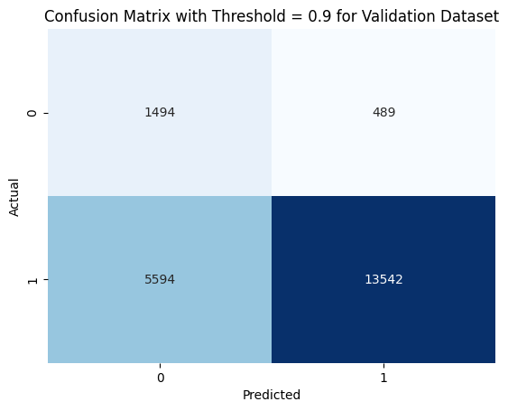

```python
# Apply the 0.9 decision threshold
log_reg_preds_train_threshold = (y_probs >= 0.9).astype(int)
log_reg.fit(X_train, y_train)
y_probs = log_reg.predict_proba(X_valid)[:, 1]
log_reg_preds_valid_threshold = (y_probs >= 0.9).astype(int)

# Print the classification report
print("Classification Report for Training Dataset with Threshold = 0.9:")
print(classification_report(y_train, log_reg_preds_train_threshold))
print("Classification Report for Validation Dataset with Threshold = 0.9:")
print(classification_report(y_valid, log_reg_preds_valid_threshold))

# Plot the Confusion Matrix
cm = confusion_matrix(y_valid, log_reg_preds_valid_threshold)
sns.heatmap(cm, annot=True, fmt='d', cmap='Blues', cbar=False)

plt.xlabel('Predicted')
plt.ylabel('Actual')
plt.title('Confusion Matrix with Threshold = 0.9 for Validation Dataset')
plt.show()
```

Another way to increase recall and deal with the issue of an unbalanced dataset is by assigning a higher weight to the minority class. The class_weight parameter penalizes mistakes in samples of class[i] with class_weight[i] instead of 1. We will now analyze if this gives us better results than changing the decision threshold or if we should take both of these approaches.

```python
# Final Model with balanced class weights
log_reg = LogisticRegression(solver="lbfgs", penalty="l2", C = 1.0, class_weight="balanced")
log_reg_preds_train = cross_val_predict(log_reg, X_train, y_train, cv=5)

#log_reg.fit(X_train, y_train)

# Print the classification report
print("Performance on Training Dataset : \n\n", classification_report(y_train, log_reg_preds_train))
```

```
Performance on Training Dataset :

               precision    recall  f1-score   support

       False       0.19      0.78      0.30      4414
        True       0.97      0.67      0.79     44861

    accuracy                           0.68     49275
   macro avg       0.58      0.73      0.55     49275
weighted avg       0.90      0.68      0.75     49275
```

```python
# Try different class weights and check how that influences the f1-score
class_weights = [1, 2, 3, 5, 10, 15, 20]
f1_scores_group0 = []

# Iterate over the different class_weight values for group 0
for weight in class_weights:
    # Set custom class weights with group 0 weight adjusted
    custom_weights = {0: weight, 1: 1.0}

    # Initialize and train the Logistic Regression model
    log_reg = LogisticRegression(solver="lbfgs",penalty="l2", C = 1.0, class_weight=custom_weights)
    log_reg_preds_train = cross_val_predict(log_reg, X_train, y_train, cv=4)

    # Calculate F1 score for group 0
    f1_group0 = f1_score(y_train, log_reg_preds_train, pos_label=0)
    f1_scores_group0.append((weight, f1_group0))

    print(f"Class weight for group 0: {weight}, F1 Score for group 0: {f1_group0}")
```

```
Class weight for group 0: 1, F1 Score for group 0: 0.02890932982917214
Class weight for group 0: 2, F1 Score for group 0: 0.16939890710382513
Class weight for group 0: 3, F1 Score for group 0: 0.2765719955351606
Class weight for group 0: 5, F1 Score for group 0: 0.3322869611821453
Class weight for group 0: 10, F1 Score for group 0: 0.3057068857729749
Class weight for group 0: 15, F1 Score for group 0: 0.2768985044286337
Class weight for group 0: 20, F1 Score for group 0: 0.26004728132387706
```

We find that the highest F1 score is reached with class_weights = {0: 5, 1: 1.0}. Therefore, we will stick to this ratio for our final model and now check if it is still worth it to change the decision threshold.

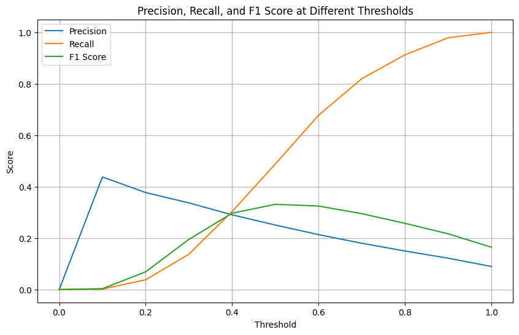

```python
# Final Model with balanced class weights
log_reg = LogisticRegression(solver="lbfgs",class_weight={0: 5, 1: 1.0}, penalty ="l2", C=1.0)

# Get predicted probabilities for the positive class (1)
y_probs = cross_val_predict(log_reg, X_train, y_train, cv=5, method='predict_proba')[:, 1]

# Define thresholds to test
thresholds = np.arange(0.0, 1.1, 0.1)
metrics = {'threshold': [], 'precision': [], 'recall': [], 'f1': []}

for threshold in thresholds:
    precision, recall, f1 = evaluate_threshold(threshold, y_train, y_probs)
    metrics['threshold'].append(threshold)
    metrics['precision'].append(precision)
    metrics['recall'].append(recall)
    metrics['f1'].append(f1)

# Plot the metrics
plt.figure(figsize=(10, 6))
plt.plot(metrics['threshold'], metrics['precision'], label='Precision')
plt.plot(metrics['threshold'], metrics['recall'], label='Recall')
plt.plot(metrics['threshold'], metrics['f1'], label='F1 Score')
plt.xlabel('Threshold')
plt.ylabel('Score')
plt.title('Precision, Recall, and F1 Score at Different Thresholds')
plt.legend()
plt.grid()
plt.show()
```

We can see that with the finetuned class weights, a threshold of 0.5 maximizes the F1 score. We will now apply this threshold to the model to decide if the logistic regression works better or worse with changed class weights.

```
Classification Report for Validation Dataset with Threshold = 0.5:
              precision    recall  f1-score   support

       False       0.27      0.50      0.35      1983
        True       0.94      0.86      0.90     19136

    accuracy                           0.82     21119
   macro avg       0.61      0.68      0.62     21119
weighted avg       0.88      0.82      0.85     21119
```

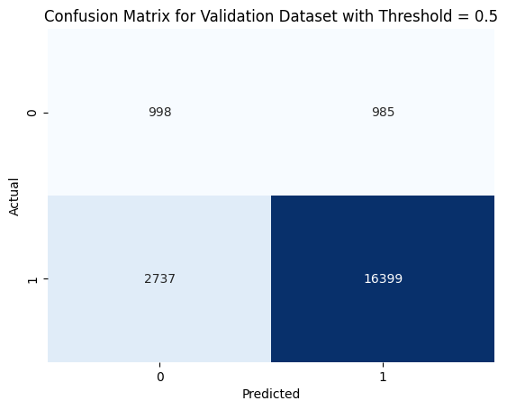

```python
# Apply the 0.5 decision threshold
log_reg.fit(X_train, y_train)
y_probs = log_reg.predict_proba(X_valid)[:, 1]
log_reg_preds_valid_threshold = (y_probs >= 0.5).astype(int)

# Generate the classification report as a dictionary
report = classification_report(y_valid, log_reg_preds_valid_threshold, output_dict=True)

# Print the classification report
print("Classification Report for Validation Dataset with Threshold = 0.5:")
print(classification_report(y_valid, log_reg_preds_valid_threshold))

# Plot the Confusion Matrix
cm = confusion_matrix(y_valid, log_reg_preds_valid_threshold)
sns.heatmap(cm, annot=True, fmt='d', cmap='Blues', cbar=False)

plt.xlabel('Predicted')
plt.ylabel('Actual')
plt.title('Confusion Matrix for Validation Dataset with Threshold = 0.5')
plt.show()
```

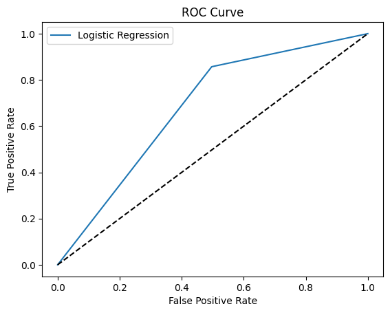

```
AUC Score: 0.6801245078358353
```

```python
# ROC plot for the Logistic Regression Model (Final Model)
tpr, fpr, thresholds = roc_curve(y_valid, log_reg_preds_valid_threshold, pos_label=0)
plt.plot(fpr, tpr, label='Logistic Regression')
plt.plot([0, 1], [0, 1], 'k--')
plt.xlabel('False Positive Rate')
plt.ylabel('True Positive Rate')
plt.title('ROC Curve')
plt.legend()
plt.show()

print("AUC Score:", roc_auc_score(y_valid, log_reg_preds_valid_threshold))
```

The ROC curve depicts the trade-off between true positive rate (sensitivity) and false positive rate (specificity) for different classification thresholds. In this case, the Logistic Regression model demonstrates a good performance with a clear separation from the diagonal line, indicating that it is better than random guessing. The AUC score is 0.68, which is higher than the AUC score of random guessing (0.5).

```python
# Store values for final comparison
# Mount Google Drive
drive.mount('/content/drive')

# Specify file path in Google Drive
file_path = '/content/drive/My Drive/IDS_model_metrics.xlsx'

def save_metrics_to_csv(
    model_name, accuracy, recall_false, f1_score_false, f1_score_weighted, f1_score_macro,
    file_path='/content/drive/My Drive/IDS_model_metrics.csv'):
    """
    Saves model metrics to an csv file.

    Parameters:
    - model_name (str): Name of the model.
    - accuracy (float): Accuracy of the model.
    - recall_false (float): Recall for the 'False Group'.
    - f1_score_false (float): F1 score for the 'False Group'.
    - f1_score_weighted (float): Weighted average F1 score.
    - f1_score_macro (float): Macro average F1 score.
    - file_path (str): Path to the Excel file (default: 'IDS_model_metrics.csv').
    """
    # Create a DataFrame with the metrics
    data = {
        "Model Name": [model_name],
        "Accuracy": [accuracy],
        "Recall (False Group)": [recall_false],
        "F1 Score (False Group)": [f1_score_false],
        "Weighted Avg F1 Score": [f1_score_weighted],
        "Macro Avg F1 Score": [f1_score_macro]
    }

    df = pd.DataFrame(data)

    # Check if file exists
    if os.path.exists(file_path):
        # If file exists, append without writing the header
        df.to_csv(file_path, mode='a', header=False, index=False)
    else:
        # If file does not exist, create it with a header
        df.to_csv(file_path, mode='w', header=True, index=False)
```

```python
# Generate the classification report as a dictionary
report = classification_report(y_valid, log_reg_preds_valid_threshold, output_dict=True)

# Extract metrics from the report
accuracy = report["accuracy"]
recall_false = report["False"]["recall"]
f1_score_false = report["False"]["f1-score"]
f1_score_weighted = report["weighted avg"]["f1-score"]
f1_score_macro = report["macro avg"]["f1-score"]


# Save them in csv file
save_metrics_to_csv(
    model_name="logistic regression with imbalanced data",
    accuracy=accuracy,
    recall_false=recall_false,
    f1_score_false=f1_score_false,
    f1_score_weighted=f1_score_weighted,
    f1_score_macro=f1_score_macro,
    file_path='/content/drive/My Drive/IDS_model_metrics.csv'
)
```

## K-Nearest Neighbor

Next, the K-Nearest Neighbor (KNN) algorithm will be implemented. This is a classification algorithm that works by calculating the distance between the data point to be predicted and the other points in the feature space to find its nearest neighbors. The "K" specifies the number of neighbors to consider. The algorithm then assigns the data point to the class that is most common among its K nearest neighbors. The choice of K as well as the distance metric are important hyperparameters and influence the algorithm's performance. As a distance metric, we should use the Euclidean norm "L2" because our data is already well standardized and no significant gains are expected for different distance norms. It is noteworthy that kNN is a computationally very demanding model. Therefore, we decided to not use cross-validation to shorten the runtime.

```python
k_neighbors = np.arange(3,20,2)
train_recall = {}
valid_recall = {}

for k in k_neighbors:
  knn = KNeighborsClassifier(n_neighbors=k, metric='euclidean')
  knn.fit(X_train, y_train)
  knn_preds_train = knn.predict(X_train)
  knn_preds_valid = knn.predict(X_valid)

  # Calculate the recall score
  train_recall[k] = recall_score(y_train, knn_preds_train, pos_label=0)
  valid_recall[k] = recall_score(y_valid, knn_preds_valid, pos_label=0)

print(train_recall)
print(valid_recall)
```

```
{3: 0.31422745808790215, 5: 0.1676483914816493, 7: 0.10602628001812416, 9: 0.07045763479836882, 11: 0.053919347530584506, 13: 0.04191209787041233, 15: 0.03420933393747168, 17: 0.02945174444947893, 19: 0.02650657000453104}
{3: 0.10237014624306606, 5: 0.06354009077155824, 7: 0.0448814926878467, 9: 0.040342914775592535, 11: 0.03328290468986384, 13: 0.02773575390821987, 15: 0.022188603126575897, 17: 0.018658598083711547, 19: 0.017650025214321734}
```

The results demonstrate that the algorithm exhibits optimal performance when a smaller number of neighbors is utilized. The selection of the number of neighbors is highly dependent on the dataset. While more neighbors bring in more information, this can make it harder to distinguish between categories, especially along the class boundaries. For low values of k, the model focuses closely on individual data points. This high sensitivity to local data points can, however, lead to overfitting, as the model may capture noise rather than the general pattern of the data. It is also important to note that as the number of neighbors increases, the computational intensity of the task also increases. In conclusion, it is important to find the sweet spot for the value of k. Moreover, the number of neighbors should be odd to prevent ties in the majority vote. In our case, k=3 leads to the best result on the training as well as the validation dataset. This might be due to the imbalance of our data. Given that there are so few uninsured cases in the dataset, it is likely that a high k leads to a lot of non-uninsured neighbors being considered.

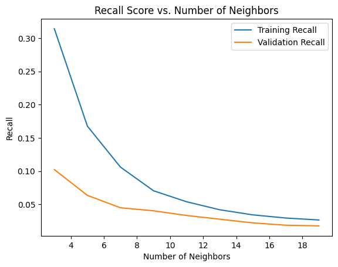

```python
plt.plot(k_neighbors, train_recall.values(), label='Training Recall')
plt.plot(k_neighbors, valid_recall.values(), label='Validation Recall')
plt.title('Recall Score vs. Number of Neighbors')
plt.xlabel('Number of Neighbors')
plt.ylabel('Recall')
plt.legend()
plt.show()
```

```
Performance on Training Dataset :

               precision    recall  f1-score   support

       False       0.25      0.10      0.15      4414
        True       0.92      0.97      0.94     44861

    accuracy                           0.89     49275
   macro avg       0.58      0.54      0.54     49275
weighted avg       0.86      0.89      0.87     49275

Performance on Validation Dataset :

               precision    recall  f1-score   support

       False       0.27      0.10      0.15      1983
        True       0.91      0.97      0.94     19136

    accuracy                           0.89     21119
   macro avg       0.59      0.54      0.54     21119
weighted avg       0.85      0.89      0.87     21119
```

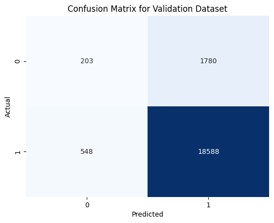

```python
# Set up Final Model
knn = KNeighborsClassifier(n_neighbors=3, metric='euclidean')
knn.fit(X_train, y_train)
knn_preds_train = cross_val_predict(knn, X_train, y_train, cv=5)
knn_preds_valid = knn.predict(X_valid)

# Print the classification report
print("Performance on Training Dataset : \n\n", classification_report(y_train, knn_preds_train))
print("Performance on Validation Dataset : \n\n", classification_report(y_valid, knn_preds_valid))

# Plot the Confusion matrix
cm = confusion_matrix(y_valid, knn_preds_valid)
sns.heatmap(cm, annot=True, fmt='d', cmap='Blues', cbar=False)

plt.xlabel('Predicted')
plt.ylabel('Actual')
plt.title('Confusion Matrix for Validation Dataset')
plt.show()
```

Similar to the logistic regression, the KNN model shows strong performance for the insured class on both the training and validation datasets but struggles with the uninsured class. In the training dataset, the model achieves high precision (0.92) and recall (0.97) for the insured class, resulting in a high F1-score of 0.94, whereas for the uninsured class, precision and recall are low at 0.25 and 0.10, respectively, yielding an F1-score of 0.15. This pattern is consistent on the validation dataset, where precision and recall for the insured class remain high (0.91 and 0.97), while the uinsured class has low precision (0.27) and recall (0.10), with an F1-score of only 0.15. In contrast to the logistic regression, we do not have any other parameters such as class_weight or decision threshold that could be tuned to resolve the issue. The similarity in performance across both the training and validation datasets indicates that there is no overfitting, as the model generalizes similarly to new data.

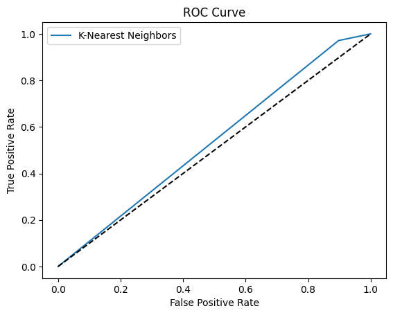

```
AUC Score: 0.5368665112486234
```

```python
# ROC plot for the KNN algorithm
tpr, fpr, thresholds = roc_curve(y_valid, knn_preds_valid, pos_label=0)
plt.plot(fpr, tpr, label='K-Nearest Neighbors')
plt.plot([0, 1], [0, 1], 'k--')
plt.xlabel('False Positive Rate')
plt.ylabel('True Positive Rate')
plt.title('ROC Curve')
plt.legend()
plt.show()

print("AUC Score:", roc_auc_score(y_valid, knn_preds_valid))
```

The poor performance of the model on the negative class is further reflected in the AUC score, which is 0.54 for the negative class. Considering that a score of 0.5 indicates random guessing, an AUC of 0.54 suggests that the model has a very limited ability to distinguish between the uninsured and insured classes when it comes to negative instances. It only performs slightly better than random guessing. This low AUC score indicates that the model is not effectively identifying negative instances, which is consistent with the low precision and recall observed for the uninsured class.

```python
# Generate the classification report as a dictionary
report = classification_report(y_valid, knn_preds_valid, output_dict=True)

# Extract metrics from the report
accuracy = report["accuracy"]
recall_false = report["False"]["recall"]
f1_score_false = report["False"]["f1-score"]
f1_score_weighted = report["weighted avg"]["f1-score"]
f1_score_macro = report["macro avg"]["f1-score"]


# Save them in csv file
save_metrics_to_csv(
    model_name="knn with imbalanced data",
    accuracy=accuracy,
    recall_false=recall_false,
    f1_score_false=f1_score_false,
    f1_score_weighted=f1_score_weighted,
    f1_score_macro=f1_score_macro,
    file_path='/content/drive/My Drive/IDS_model_metrics.csv'
)
```

## Bayesian Classifier

As a third model, we will implement a Bayesian Classifier. The only parameter which can be finetuned in a Bayesian classifier is "var_smoothing" which is used to control the amount of "smoothing" applied to the variance of the features. It is a regularization technique that prevents the model from having issues with numerical stability when variances of the features are very small or close to zero. This smoothing helps avoid overfitting to small variances that might result from noisy data or very few data points, leading to more robust predictions. The default value is 1e-9, which is rather low. We will try different values for the parameter to see how it affects our model performance.

```python
smoothing_values = [1e-1, 1e-2, 1e-3, 1e-4, 1e-5, 1e-6, 1e-7, 1e-8, 1e-9, 1e-10, 1e-11, 1e-12, 1e-13, 1e-14, 1e-15]
train_recall = {}

for smoothing in smoothing_values:
    # Set up a Bayesian Classifier and fit the model
    clf = GaussianNB(var_smoothing = smoothing)
    clf_preds_train = cross_val_predict(clf, X_train, y_train, cv=4)

    # Compute recall
    train_recall[smoothing] = recall_score(y_train, clf_preds_train, pos_label=0)

print(train_recall)
```

[output not shown]

We can see that the recall score increases when we lower the smoothing parameter until 1e-07. Therefore, we will use 1e-07 as the smoothing parameter to get the maximum recall score. By introducing a rather low amount of regularization, we make the model more sensitive to the differences in feature values and treat variances as less uniform. In this way, we make our model more complex, which is necessary for it to reliably detect uninsured clients. The reason for which the model performs best with low regularization might be that the imbalance of insurance groups makes it necessary to consider also small variances to not classify every individual as insured.

```python
# Model with correct smoothing parameter
clf = GaussianNB(var_smoothing = 1e-7)
clf_preds_train = cross_val_predict(clf, X_train, y_train, cv=5)

# Print the classification report
print("Performance on Training Dataset : \n\n", classification_report(y_train, clf_preds_train))
```

```
Performance on Training Dataset :

               precision    recall  f1-score   support

       False       0.21      0.29      0.24      4414
        True       0.93      0.89      0.91     44861

    accuracy                           0.84     49275
   macro avg       0.57      0.59      0.58     49275
weighted avg       0.86      0.84      0.85     49275
```

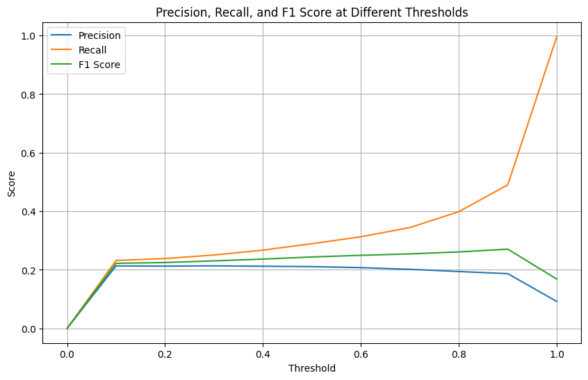

```python
# Get predicted probabilities for the positive class (1)
y_probs = cross_val_predict(clf, X_train, y_train, cv=5, method='predict_proba')[:, 1]

# Define thresholds to test
thresholds = np.arange(0.0, 1.1, 0.1)
metrics = {'threshold': [], 'precision': [], 'recall': [], 'f1': []}

for threshold in thresholds:
    precision, recall, f1 = evaluate_threshold(threshold, y_train, y_probs)
    metrics['threshold'].append(threshold)
    metrics['precision'].append(precision)
    metrics['recall'].append(recall)
    metrics['f1'].append(f1)

# Plot the metrics
plt.figure(figsize=(10, 6))
plt.plot(metrics['threshold'], metrics['precision'], label='Precision')
plt.plot(metrics['threshold'], metrics['recall'], label='Recall')
plt.plot(metrics['threshold'], metrics['f1'], label='F1 Score')
plt.xlabel('Threshold')
plt.ylabel('Score')
plt.title('Precision, Recall, and F1 Score at Different Thresholds')
plt.legend()
plt.grid()
plt.show()
```

[output not shown]

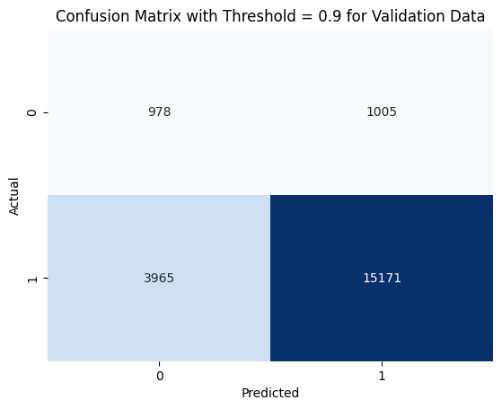

```python
# Apply the 0.9 decision threshold
clf_preds_train_threshold = (y_probs >= 0.9).astype(int)
clf.fit(X_train, y_train)
y_probs = clf.predict_proba(X_valid)[:, 1]
clf_preds_valid_threshold = (y_probs >= 0.9).astype(int)

# Print the classification report
print("Classification Report with Threshold = 0.9 for Training Data:")
print(classification_report(y_valid, clf_preds_valid_threshold))
print("Classification Report with Threshold = 0.9 for Validation Data:")
print(classification_report(y_train, clf_preds_train_threshold))

# Plot the Confusion Matrix
cm = confusion_matrix(y_valid, clf_preds_valid_threshold)
sns.heatmap(cm, annot=True, fmt='d', cmap='Blues', cbar=False)

plt.xlabel('Predicted')
plt.ylabel('Actual')
plt.title('Confusion Matrix with Threshold = 0.9 for Validation Data')
plt.show()
```

In comparison to the decision threshold of 0.5, we were able to signficiantly increase the recall score to 0.49 and the F1 score to 0.27. The accuracy naturally decreased, though we should not consider the accuracy as very important given the skewness of our dataset. With the finetuned parameters and a threshold of 0.9, the Bayesian classifier performs significantly better than the knn model and slightly worse than the Logistic Regression. While the Logistic Regression model has a higher F1 score and a more balanced tradeoff between precision and recall, the Bayesian classifier leads to a relatively high recall and low precision.